# Chapter 4 Problems

# First Assignment

Easy 1 2 3 (on paper) and Medium 1 2

# 4M1

Simulate observed heights from the prior (not the posterior):

y_i ~ Normal(mu, sigma) mu ~ Normal(0, 10) sigma ~ Uniform(0, 10)

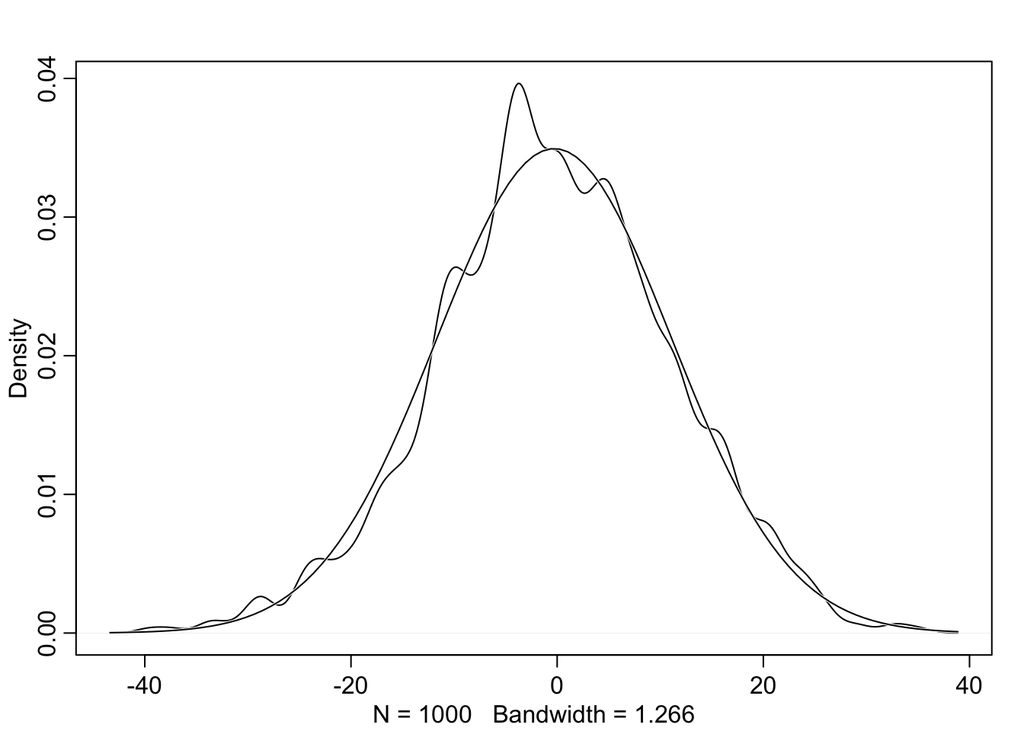

```r
n_samples = 1000
samples <- rnorm(n_samples,
                 mean = rnorm(n_samples, mean = 0, sd = 10),
                 sd = runif(n = n_samples, min = 0, max = 10))
dens(samples, norm.comp = TRUE)
```

```r
# sd(samples)
```

# 4M2

Translate the model from 4M1 into a `map` formula:

```r
formulas <- alist(
  y ~ dnorm(mu, sigma),
  mu ~ dnorm(0, 10),
  sigma ~ Uniform(0, 10)
)

# If we had data, we'd then do:
# model <- rethinking::map(formulas, data)
# precis(model)
```

# Second Assignment

M 3 4 (on paper) and H 1 2 3

# 4H1

Provide predicted heights and 89% intervals (either HPDI or PI) for each of these individuals using model-based predictions.

```r
formulas <- alist(
  height ~ dnorm(mu, sigma),
  mu <- a + b * weight,
  a ~ dnorm(75, 20),
  b ~ dnorm(10, 10),
  sigma ~ dunif(0, 20)
)

model4h1 <- rethinking::map(flist = formulas, data = df)

results <- data.frame(weight = c(46.95, 43.72, 64.78, 32.59, 54.63))
mus <- rethinking::link(model4h1, data = results)
results$height <- apply(mus, 2, mean)
results$HPDI_lower <- apply(mus, 2, HPDI, prob = 0.89)[1,]
results$HPDI_upper <- apply(mus, 2, HPDI, prob = 0.89)[2,]
results
```

[output not shown]

# 4H2

Select all the rows of Howell1 with ages below 18 (should have 192 rows).

```r
youth <- df %>% filter(age < 18)
lengths(youth)
```

```
## height weight    age   male
##    192    192    192    192
```

## Part A

Fit a linear regression using `map`. Present and interpret the estimates.

```r
formulas <- alist(
  height ~ dnorm(mu, sigma),
  mu <- a + b * weight,
  a ~ dnorm(100, 100),
  b ~ dnorm(100, 100),
  sigma ~ dunif(0, 100)
)

model4h2a <- rethinking::map(flist = formulas, data = youth)
precis(model4h2a)
```

```
##        Mean StdDev  5.5% 94.5%
## a     58.24   1.40 56.01 60.47
## b      2.72   0.07  2.61  2.83
## sigma  8.44   0.43  7.75  9.13
```

For every 10 units of increase in weight, the model predicts that the child will get 27.2cm taller (because the coefficient of b is 2.72).

## Part B

Plot the raw data, with height on the vertical axis and weight on the horizontal oaxis. Suprimpose he MAP regression line and 89% HPDI for the mean. Also superimpose the 89% HPDI for predicted heights.

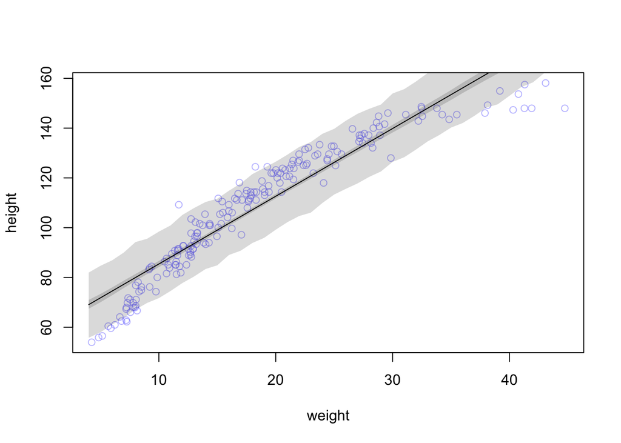

```r
# Set up grid of weights
weight.seq = seq(floor(min(youth$weight)), ceiling(max(youth$weight)))

# Sample from the posterior and compute summary statistics
post <- extract.samples(model4h2a)
mu <- link(model4h2a, data = data.frame(weight = weight.seq))
mu.mean <- apply(mu, 2, mean)
mu.HPDI <- apply(mu, 2, rethinking::HPDI)

# Issue height predictions and compute intervals
sim.height <- sim(model4h2a, data = list(weight = weight.seq))
height.PI <- apply(sim.height, 2, PI, prob = 0.89)

# Plot model in top of data
plot(height ~ weight, data = youth, col = col.alpha(rangi2, 0.5))
lines(weight.seq, mu.mean)
shade(mu.HPDI, weight.seq)
shade(height.PI, weight.seq)
```

## Part C

What aspects of the model fit concern you? Describe the kinds of assumptions you would change, if any, to improve the model. You don’t have to write any new code. Just explain what the model appears to be doing a bad job of, and what you hypothesize would be a better model.

*It looks like rates of growth of height and weight are not uniform and are changing over time. A linear model, which assumes both rates are constant, isn’t doing a great job of capturing this. It’s particularly pronounced toward the end of childhood once the major growth spurts are finished and the child is just gaining weight but not as much height. I’d rather choose a model that flattens out as adulthood approaches, either a log or a piecewise model*

# 4H3

Try the model “logarithm of body weigth scales with height.”

## Part A

Model the relationship between height (cm) and the natural log of weight (log_kg). Use the entire Howell1 dataframe. Fit this model using the quadratic approximation [see book]. Interpret the resulting estimates.

```r
formulas <- alist(
  height ~ dnorm(mu, sigma),
  mu <- a + b * log(weight),
  a ~ dnorm(100, 100),
  b ~ dnorm(10, 100),
  sigma ~ dunif(0, 100)
)

model4h3 <- rethinking::map(flist = formulas, data = df)
precis(model4h3)
```

```
##         Mean StdDev   5.5%  94.5%
## a     -23.80   1.33 -25.93 -21.66
## b      47.08   0.38  46.47  47.69
## sigma   5.13   0.16   4.89   5.38
```

So the intercept is -23.80, which is kind of hard to interpret since we didn’t recenter the data before plotting. I don’t think it’s super meaningful on its own.

Beta is 47.08, so for every time `log(weight)` goes up by 1 (so the weight goes up by a factor of *e*) the height goes up 47.08cm.

This is not much easier to interpret than the linear version, hopefully the plot looks better!

## Part B

Use samples from the quadratic approximate posterior of the model in (a) to create a plot of the raw data with the following superimposed:

1. the predicted mean height as a function of weight
2. the 97% HPDI for the mean, and the
3. the 97% HPDI for predicted heights

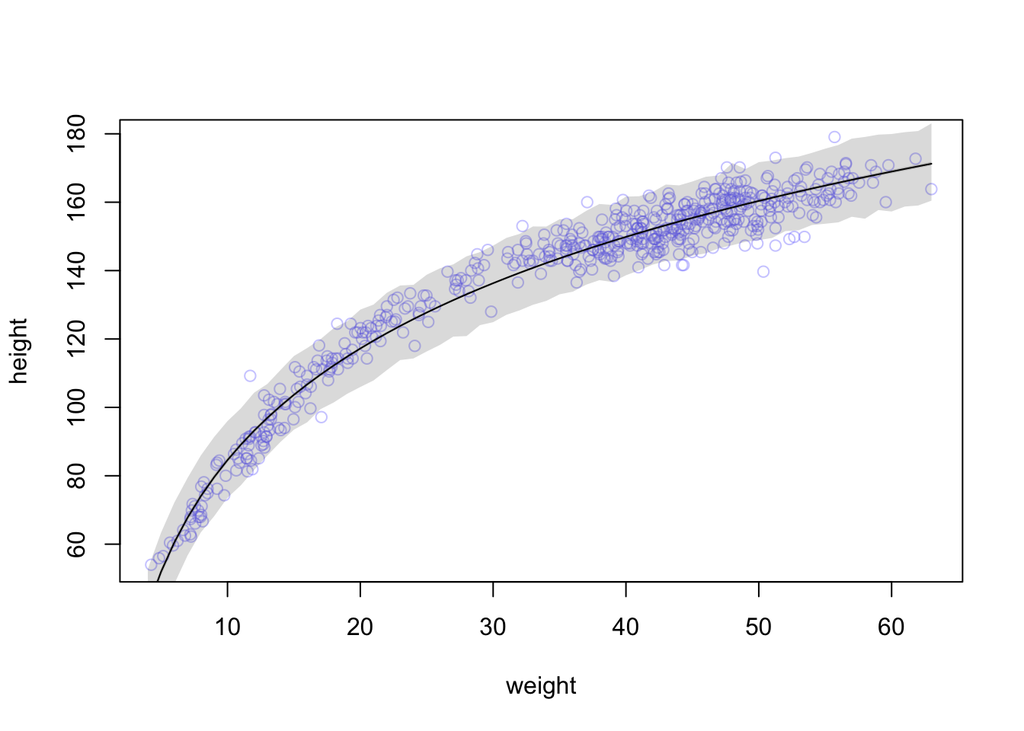

```r
model <- model4h3
interval = 0.97

# Set up grid of weights
weight.seq = seq(floor(min(df$weight)), ceiling(max(df$weight)))

# Sample from the posterior and compute summary statistics
post <- extract.samples(model)
mu <- link(model, data = data.frame(weight = weight.seq))
mu.mean <- apply(mu, 2, mean)
mu.HPDI <- apply(mu, 2, rethinking::HPDI)

# Issue height predictions and compute intervals
sim.height <- sim(model, data = list(weight = weight.seq))
height.PI <- apply(sim.height, 2, PI, prob = interval)

# Plot model in top of data
plot(height ~ weight, data = df, col = col.alpha(rangi2, 0.4))
lines(weight.seq, mu.mean)
shade(mu.HPDI, weight.seq)
shade(height.PI, weight.seq)
```

[output not shown]